# Pair Trading in R

Marcos Jaen

2024-06-03

# Statistical Arbitrage and Pair Trading

**Statistical Arbitrage** involves using statistical methods to identify trading opportunities based on mean reversion. It leverages short-term price movements and statistical properties of time series data.

**Pair Trading** is a type of statistical arbitrage where two correlated securities are traded simultaneously. The idea is to exploit the relative price movements of the pair:

## 1. Mean Reversion

If two securities are cointegrated, deviations from their historical relationship are expected to revert to the mean. Traders can short the overperforming security and long the underperforming one.

## 2. Spread

The difference between the prices of the two securities. When the spread deviates significantly from its mean, a trade is initiated based on the expectation that the spread will revert.

## Key Concepts:

**1. Stationarity:** A stationary time series has a constant mean, variance, and autocorrelation structure over time.

**2. Non-Stationarity:** Most financial time series are non-stationary, meaning their statistical properties change over time. However, differences between such series can be stationary.

**4. Johansen Test:** A statistical test for cointegration that uses a vector autoregressive model to test for the presence of cointegration relationships among multiple time series.

**5. Augmented Dickey-Fuller (ADF) Test:** A test for stationarity that checks whether a time series has a unit root. For cointegration, the residuals from the cointegrated series should be stationary.

# Summary of the Process

## 1. Data Preparation

Load the necessary packages. Read the data and filter it to include only relevant rows and columns. Select data for the year 2019 and ensure there are at least 250 trading days for each symbol. Pivot the data to have symbols as columns and dates as rows.

## 2. Correlation Analysis

Calculate the correlation matrix for the numeric data (closing prices). Identify pairs of symbols with a high correlation (above 0.7) and remove redundant pairs.

## 3. Cointegration Testing

For each pair of highly correlated symbols, test for cointegration using the Johansen test. If the test indicates cointegration, perform an Augmented Dickey-Fuller (ADF) test on the residuals to confirm stationarity.

## 4. Filtering Pairs

Merge the identified cointegrated pairs with additional benchmark and currency information. Filter the pairs based on specific criteria such as different benchmarks but the same currency, test benchmarks’ names similarity using Levenshtein distance.

## 5. Plotting and Analysis

Plot the time series of the identified pairs. Implement a Kalman filter to dynamically adjust the hedge ratio and intercept. Generate trading signals based on deviations from the mean (standard deviation bands).

## 6. Backtesting

Simulate positions based on the trading signals. Calculate the P&L (Profit and Loss) from these positions. Plot the cumulative P&L to evaluate the performance of the strategy.

# R Code Implementation

**1. Identify Pairs:** Use correlation and cointegration tests to find pairs of securities that historically move together.

```r
# Load required packages
options(max.print=999999)
pacman::p_load(dplyr, janitor, tidyr, tidyverse, fuzzyjoin, stringr, zoo, data.table, xts, urca, tseries)

# Read the data
filename <- 'T:\\Strategy_Operations\\Economics Analysis\\Data Sources folder mirrored on OSCER\\Research and Analysis Policy Projects\\CSA ETF Research\\MCortes\\MAP Data\\full.data.final.csv'
data <- fread(filename)

# Filter and prepare the data
df <- data %>%
  filter(!is.na(bloomberg.closing_price)) %>%
  distinct(sym, date, bloomberg.closing_price) %>%
  mutate(year = format(as.Date(date, format='%Y.%m.%d'),"%Y")) %>%
  filter(year == 2019) %>%
  group_by(sym) %>%
  arrange(date) %>%
  filter(n() >= 250) %>%
  fill(bloomberg.closing_price, .direction = "down") %>%
  ungroup() %>%
  pivot_wider(names_from = "sym", values_from = "bloomberg.closing_price") %>%
  dplyr::select(-year)
print(df)
```

```
## # A tibble: 251 × 297
##    date         BGU BKL.F  CAGG   CBH   CBO   CCX   CDZ   CEW   CGL   CGR   CHB
##    <IDate>    <dbl> <dbl> <dbl> <dbl> <dbl> <dbl> <dbl> <dbl> <dbl> <dbl> <dbl>
##  1 2019-01-02  21.1  17.8  47.7  18.4  18.2  5.5   23.7  11.2  11.0  27.4  17.3
##  2 2019-01-03  20.6  17.9  48.1  18.4  18.3  5.8   23.6  11.1  11.0  27.3  17.4
##  3 2019-01-04  21.1  18.2  47.8  18.4  18.3  6.1   23.8  11.2  11    27.9  17.7
##  4 2019-01-07  21    18.3  47.9  18.4  18.2  6.15  24.0  11.2  11.0  27.7  17.8
##  5 2019-01-08  21.1  18.4  47.9  18.4  18.2  6.5   24.2  11.3  11.0  27.9  17.8
##  6 2019-01-09  21.2  18.3  47.8  18.4  18.2  7.11  24.5  11.5  11.0  27.8  18.0
##  7 2019-01-10  21.2  18.3  47.9  18.4  18.3  7.2   24.7  11.6  11.0  28.2  18.0
##  8 2019-01-11  21.2  18.3  47.9  18.4  18.3  7.1   24.8  11.6  11.0  28.5  18.0
##  9 2019-01-14  21.3  18.2  47.9  18.4  18.3  6.91  24.8  11.6  11.0  28.3  18.0
## 10 2019-01-15  21.5  18.2  47.9  18.4  18.3  7.24  25.0  11.7  11.0  28.5  18.0
## # ℹ 241 more rows
## # ℹ 285 more variables: CIE <dbl>, CIF <dbl>, CJP <dbl>, CLG <dbl>, CLU <dbl>,
## #   CMR <dbl>, COW <dbl>, CPD <dbl>, CRQ <dbl>, CSD <dbl>, CUD <dbl>,
## #   CVD <dbl>, CWO <dbl>, CWW <dbl>, CYBR <dbl>, DGRC <dbl>, DIVS <dbl>,
## #   DLR <dbl>, DXB <dbl>, DXG <dbl>, DXP <dbl>, DXU <dbl>, EQL <dbl>,
## #   FCCD <dbl>, FCID <dbl>, FCRR <dbl>, FCUD <dbl>, FHQ <dbl>, FIE <dbl>,
## #   FLCI <dbl>, FLEM <dbl>, FLUS <dbl>, FSL <dbl>, HAB <dbl>, HAC <dbl>, …
```

2. Calculate correlations and identify pairs

```r
df.corr <- df %>% dplyr::select(where(is.numeric))
df_pairs <- cor(df.corr) %>%
  as.data.frame() %>%
  mutate(var1 = rownames(.)) %>%
  gather(var2, value, -var1) %>%
  arrange(desc(value)) %>%
  group_by(value) %>%
  filter(row_number() == 1) %>%
  filter(value > 0.7, !var1 == var2)
print(df_pairs)
```

```
## # A tibble: 13,757 × 3
## # Groups:   value [13,757]
##    var1  var2  value
##    <chr> <chr> <dbl>
##  1 XQQ   QQC.F 1.00
##  2 ZQQ   XQQ   1.00
##  3 ZSP   VFV   1.00
##  4 ZQQ   QQC.F 1.00
##  5 ZUE   VSP   1.00
##  6 XUU   VUN   0.999
##  7 ZSP   XUS   0.999
##  8 ZUE   XSP   0.999
##  9 XUH   VUS   0.999
## 10 ZUE   HSU   0.999
## # ℹ 13,747 more rows
```

3. Test for cointegration

```r
# Initialize an empty dataframe to store cointegrated pairs
cointegrated_pairs <- data.frame(pair1 = character(), pair2 = character(), stringsAsFactors = FALSE)

# Test for cointegration
for (i in 1:nrow(df_pairs)) {
  pair <- df_pairs[i, ]
  name1 <- pair[1]
  name2 <- pair[2]

  values1 <- df[[as.character(name1)]]
  values2 <- df[[as.character(name2)]]

  # Perform Johansen cointegration test
  test <- summary(urca::ca.jo(data.frame(values1, values2), type="trace", K=2, ecdet="none", spec="longrun"))

  if (test@teststat[1] > test@cval[5] && test@teststat[2] > test@cval[6]) {
    index <- match(max(test@lambda), test@lambda)
    if (index == 1) {
      s <- values1 * test@V[1] + values2 * test@V[2]
    } else {
      s <- values1 * test@V[3] + values2 * test@V[4]
    }

    cointegration_test_result <- tseries::adf.test(s)
    if (cointegration_test_result$p.value < 0.05) {
      cointegrated_pairs <- rbind(cointegrated_pairs, data.frame(pair1 = as.character(name1), pair2 = as.character(name2), stringsAsFactors = FALSE))
    }
  }
}
# Merge cointegrated_pairs with external df with additional benchmark data and filter the results
join.key <- fread('T:\\Strategy_Operations\\Economics Analysis\\Data Sources folder mirrored on OSCER\\Research and Analysis Policy Projects\\CSA ETF Research\\MCortes\\join.key.csv')
cointegrated_pairs.final <- merge(cointegrated_pairs, join.key[,c(1,39,41)], by.x = "pair1", by.y = "sym", all.x = TRUE) %>%
  rename("Benchmark.1" = "Primary Prospectus Benchmark", "Currency.1" = "Mornigstar.Currency")

cointegrated_pairs.final <- merge(cointegrated_pairs.final, join.key[,c(1,39,41)], by.x = "pair2", by.y = "sym", all.x = T) %>%
  rename("Benchmark.2" = "Primary Prospectus Benchmark", "Currency.2" = "Mornigstar.Currency")


cointegrated_pairs.final <- cointegrated_pairs.final %>%
  mutate(Benchmark.1 = toupper(Benchmark.1), Benchmark.2 = toupper(Benchmark.2)) %>%
  filter(!Benchmark.1 == Benchmark.2, Currency.1 == Currency.2) %>%
  mutate(distance = 1 - RecordLinkage::levenshteinSim(Benchmark.1, Benchmark.2)) %>%
  arrange(distance) %>%
  filter(distance > 0.55) %>%
  filter(!(Benchmark.1 %in% c("","N/A") | Benchmark.2 %in% c("","N/A")),
         !(Currency.1 %in% c("","N/A") | Currency.2 %in% c("","N/A")))

cointegrated_pairs.final <- merge(cointegrated_pairs.final, df_pairs, by.x = c('pair1', 'pair2'), by.y = c('var1', 'var2'), all.x = TRUE) %>%
  rename("corr" = "value") %>%
  arrange(corr)

# Print cointegrated pairs
print(cointegrated_pairs)
```

```
##    pair1 pair2
## 1    ZCN   XIC
## 2    PXC   CRQ
## 3    XIC   VCN
## 4    ZMI   HXU
## 5    ZMI   VCE
## 6    ZMI   XIC
## 7   VCNS   HAC
## 8    XML   TLV
## 9    HAC   DXG
## 10   HAC   DXU
## 11   XTR  DGRC
## 12   XSI   DXU
## 13   VMO   HAC
## 14   ZWE   RCD
```

[output cut: 35 more lines]

4. Plot the data for one Cointegrated Pair

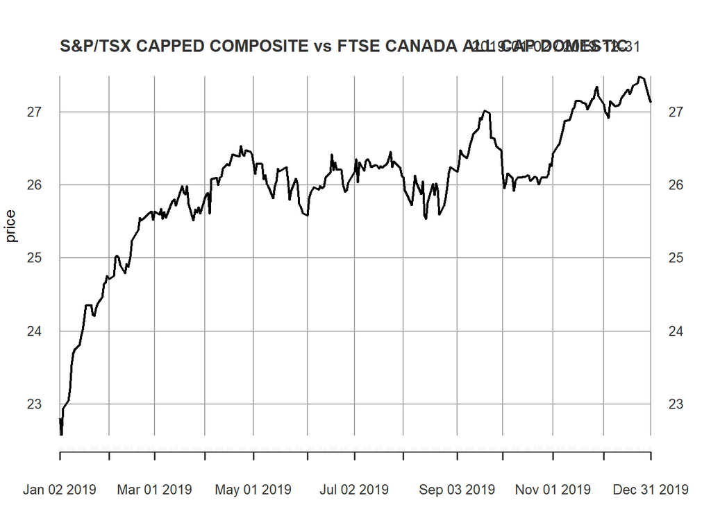

```r
library(xts)
df$date <- as.Date(df$date)
df <- as.xts(df[, -1], order.by = df$date)
plot(df$XIC, main = "S&P/TSX CAPPED COMPOSITE vs FTSE CANADA ALL CAP DOMESTIC", xlab = "date", ylab = "price")
```

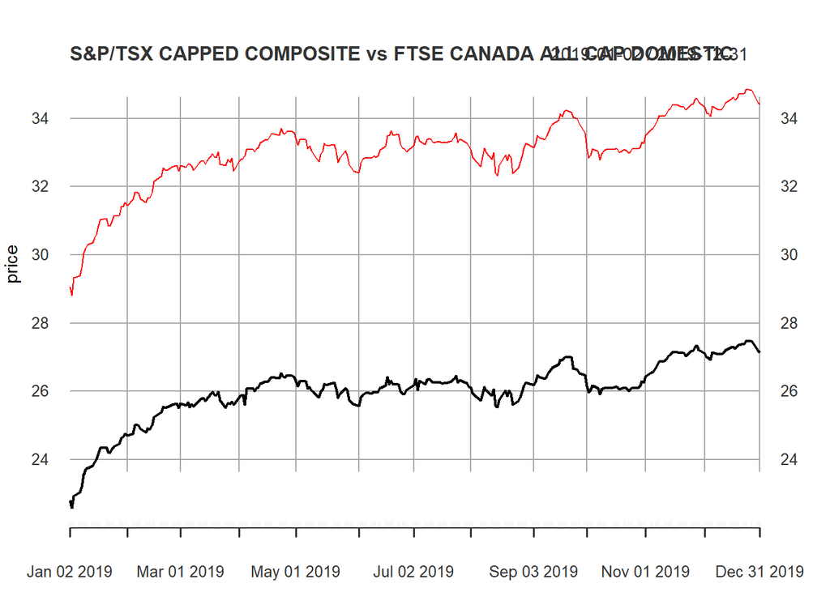

```r
lines(df$VCN, col = "red")
```

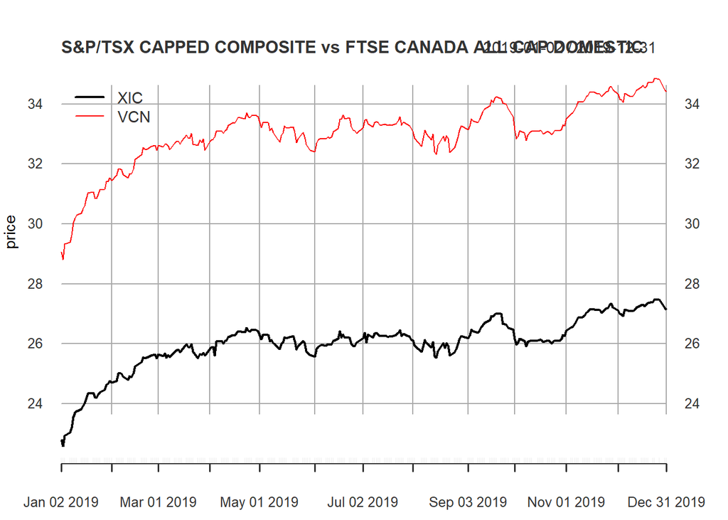

```r
addLegend("topleft", on = 1,
          legend.names = c("XIC", "VCN"),
          lty = c(1, 1), lwd = c(2, 1),
          col = c("black", "red"))
```

5. Generate Signals

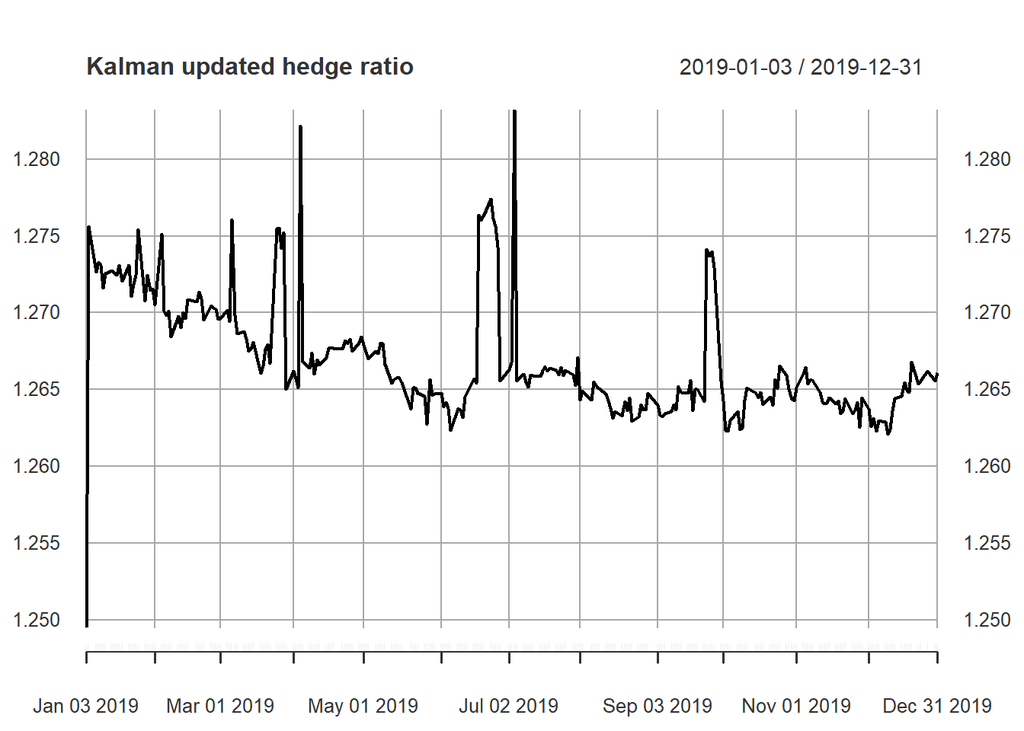

```r
x <- df$XIC
y <- df$VCN
x$int <- rep(1, nrow(x))
delta <- 0.0001
Vw <- delta/(1-delta)*diag(2)
Ve <- 0.001
R <- matrix(rep(0, 4), nrow=2)
P <- matrix(rep(0, 4), nrow=2)
beta <- matrix(rep(0, nrow(y)*2), ncol=2)
y_est <- rep(0, nrow(y))
e <- rep(0, nrow(y))
Q <- rep(0, nrow(y))
for(i in 1:nrow(y)) {
  if(i > 1) {
    beta[i, ] <- beta[i-1, ] # state transition
    R <- P + Vw # state cov prediction
  }
  y_est[i] <- x[i, ] %*% beta[i, ] # measurement prediction
  Q[i] <- x[i, ] %*% R %*% t(x[i, ]) + Ve # measurement variance prediction

  # error between observation of y and prediction
  e[i] <- y[i] - y_est[i]
  K <- R %*% t(x[i, ]) / Q[i] # Kalman gain

  # state update
  beta[i, ] <- beta[i, ] + K * e[i]
  P = R - K %*% x[i, ] %*% R
}
beta <- as.xts(beta, order.by = zoo::index(df)) #ignore date
plot(beta[2:nrow(beta), 1], type='l', main = 'Kalman updated hedge ratio')
```

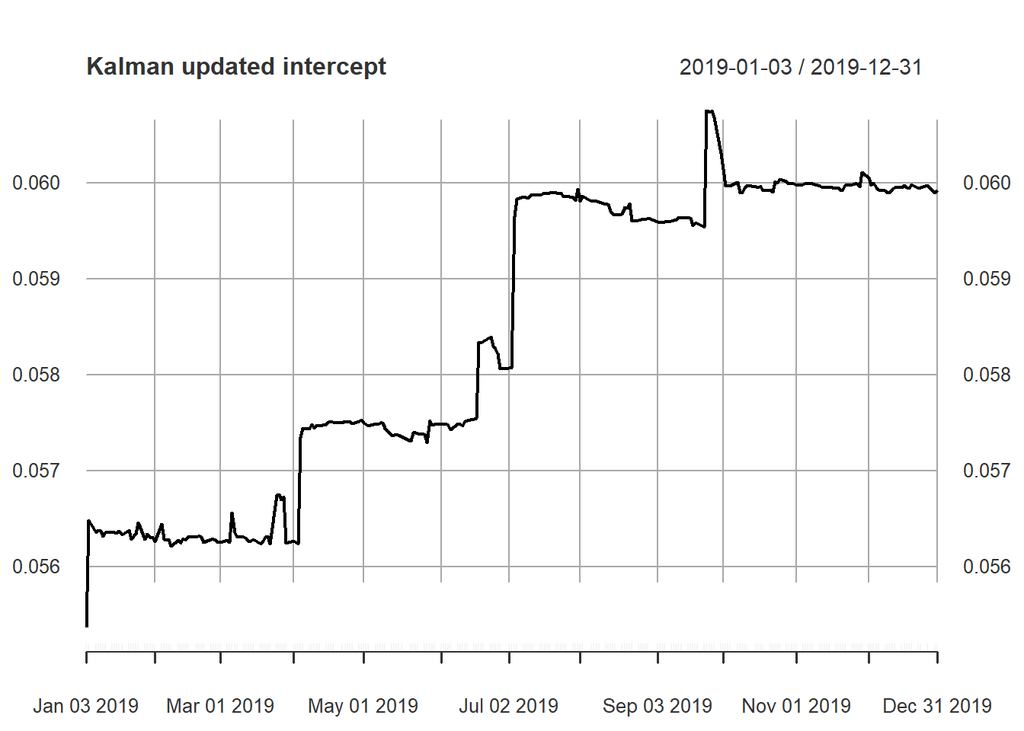

```r
plot(beta[2:nrow(beta), 2], type='l', main = 'Kalman updated intercept')
```

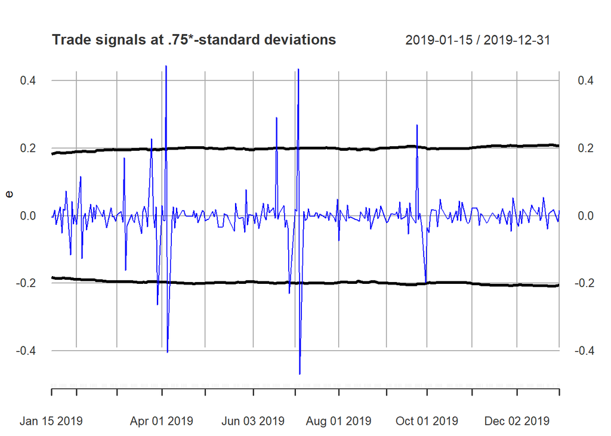

```r
# Plot trading signals at .75 standard deviation of the prediction error
e <- xts(e, order.by = zoo::index(df))
sqrtQ <- xts(sqrt(Q), order.by = zoo::index(df))
signals <- merge(e, .75 * sqrtQ, .75 * -sqrtQ)
colnames(signals) <- c("e", "sqrtQ", "negsqrtQ")
plot(signals[10:length(zoo::index(signals))], ylab = 'e',
     main = 'Trade signals at .75*-standard deviations', col = c('blue', 'black', 'black'), lwd = c(1, 3, 3))
```

6. Backtest

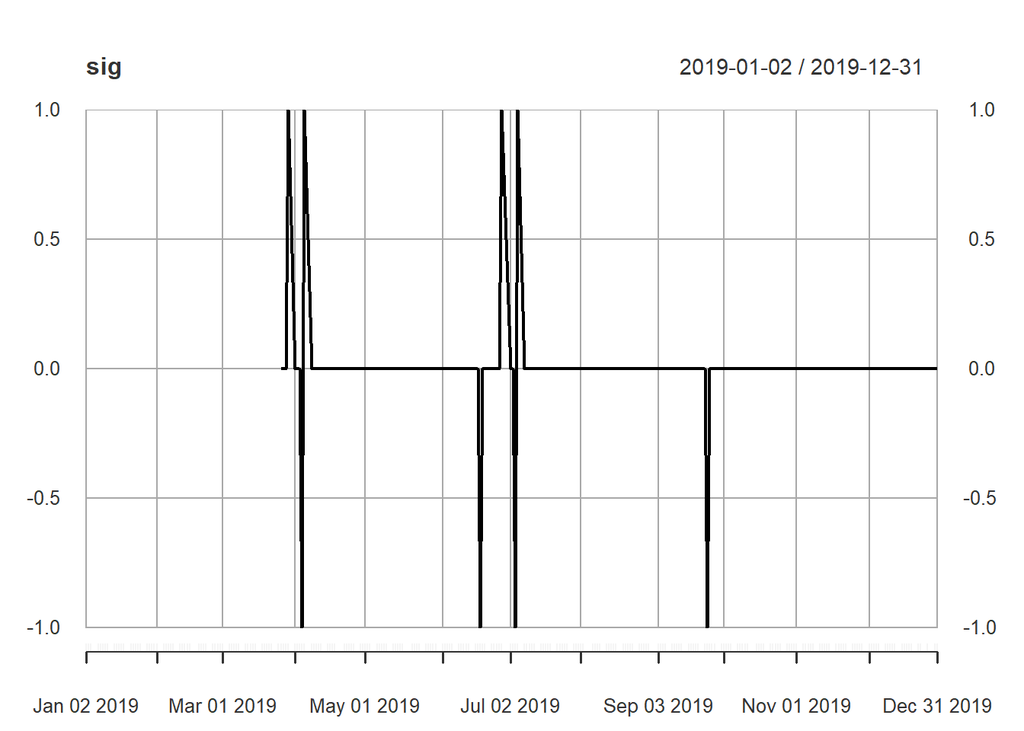

```r
# Vectorized backtest
sig <- ifelse((signals[1:length(index(signals))]$e > signals[1:length(index(signals))]$sqrtQ) & (lag.xts(signals$e, 1) < lag.xts(signals$sqrtQ, 1)), -1, ifelse((signals[1:length(index(signals))]$e < signals[1:length(index(signals))]$negsqrtQ) & (lag.xts(signals$e, 1) > lag.xts(signals$negsqrtQ, 1)), 1, 0))
colnames(sig) <- "sig"
sig[sig == 0] <- NA
sig <- na.locf(sig)
sig <- diff(sig) / 2
plot(sig)
```

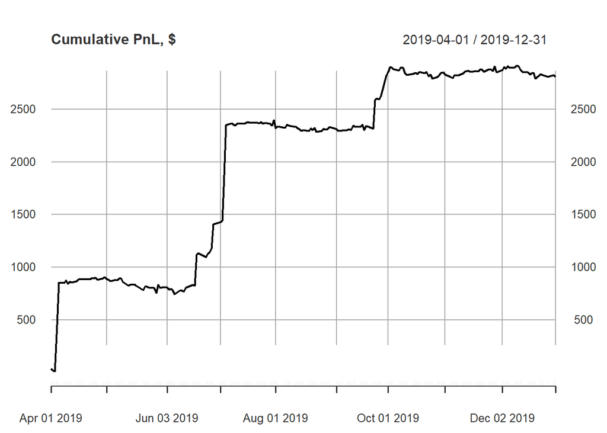

```r
# Simulate positions and PnL
sim <- merge(lag.xts(sig, 1), beta[, 1], x[, 1], y)
colnames(sim) <- c("sig", "hedge", colnames(x[, 1]), colnames(y[, 1]))
sim$posX <- sim$sig * -1000 * sim$hedge
sim$posY <- sim$sig * 1000
sim$posX[sim$posX == 0] <- NA
sim$posX <- na.locf(sim$posX)
sim$posY[sim$posY == 0] <- NA
sim$posY <- na.locf(sim$posY)
pnlX <- sim$posX * diff(sim[, colnames(x[, 1])])
pnlY <- sim$posY * diff(sim[, colnames(y[, 1])])
pnl <- pnlX + pnlY
plot(cumsum(na.omit(pnl)), main = "Cumulative PnL, $")
```